# Reproducible Research: Peer Assessment 1

## Loading and preprocessing the data

```r
library(here)
library(lubridate) # For working with date and time
library(dplyr)
library(lattice)
library(mice) # For imputation
library(VIM) # For imputation
library(stringr) # Find and replace strings in dataframe
```

```r
ok_wd <- getwd()
file_csv <- here(ok_wd, "activity.csv")
activity <- read.csv(file_csv)
activity$date <- ymd(activity$date) # Transform 'date' variable
```

## What is mean total number of steps taken per day?

1. Make a histogram of the total number of steps taken each day

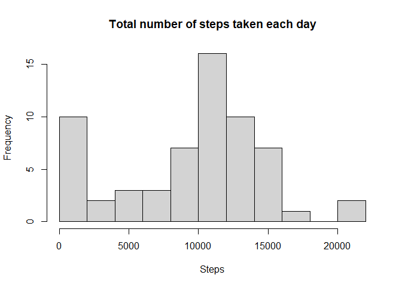

```r
total_step <- activity %>% group_by(date) %>% summarise(total = sum(steps, na.rm = TRUE))
hist(total_step$total, breaks = 8, xlab = "Steps", main = "Total number of steps taken each day")
```

2. Calculate and report the mean and median total number of steps taken per day

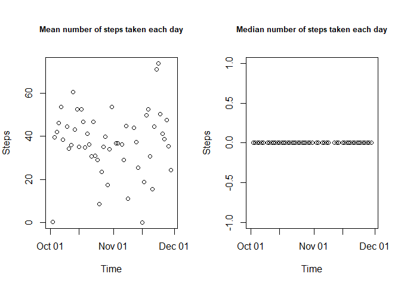

```r
mean_step_happy <- activity %>% group_by(date) %>% summarise(mean_happy = mean(steps, na.rm = TRUE))
median_step_happy <- activity %>% group_by(date) %>% summarise(median_happy = median(steps, na.rm = TRUE))

par(mfrow = c(1, 2), mar = c(5, 4, 5, 2))
plot(mean_happy ~ date, mean_step_happy, pch = 21, xlab = "Time", ylab = "Steps", main = "Mean number of steps taken each day", cex.main = 0.8)
plot(median_happy ~ date, median_step_happy, pch = 21, xlab = "Time", ylab = "Steps", main = "Median number of steps taken each day", cex.main = 0.8)
```

## What is the average daily activity pattern?

1. Make a time series plot (i.e. type = “l”) of the 5-minute interval (x-axis) and the average number of steps taken, averaged across all days (y-axis)

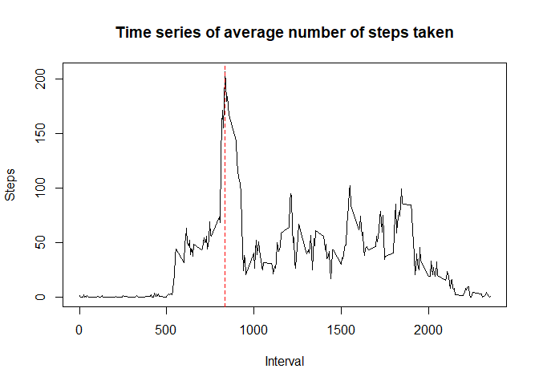

```r
time_series_happy <- activity %>% group_by(interval) %>% summarise(mean_happy = mean(steps, na.rm = TRUE))

yes_interval <- subset(time_series_happy, mean_happy == max(mean_happy))

plot(mean_happy ~ interval, data = time_series_happy, type = "l", col = "black", xlab = "Interval", ylab = "Steps", main = "Time series of average number of steps taken")

abline(v = yes_interval$interval, col="red", lty = 2)
```

2. Which 5-minute interval, on average across all the days in the dataset, contains the maximum number of steps? It is at 835th 5-min interval with average steps 206 as the red dashed line shown in the graph.